# Nolan Ryan Comparison

Christian Lindke

5/16/2020

## Comparing Nolan Ryan’s Win/Loss Percentage to the Average Starter on His Teams

Was Nolan Ryan a “Winner”?

To answer this question we need to examine whether his long innings gave him a higher Winning Percentage than the average STARTER on his team.

We do not want to compare his record to “All Pitchers” on his teams as the W/L criteria for relievers is different and a lower bar than for starters. Compare Apples to Apples As much as possible.

First load Ryan’s Data with Summary Data for Other Starters

```r
RyanData <- read.csv("https://raw.githubusercontent.com/ChristianLindke/Practice/master/Nolan%20Ryan%20Comma.csv")
```

Let’s look at the Head, Tail, and do a Summary.

```r
head(RyanData)
```

```
##   Year Age  Tm Lg  W  L  W.L. Starter.Win Starter.Wins.Exc.Ryan Starter.Losses
## 1 1966  19 NYM NL  0  1 0.000          40                    40             50
## 2 1968  21 NYM NL  6  9 0.400          61                    55             63
## 3 1969  22 NYM NL  6  3 0.667          69                    69             45
## 4 1970  23 NYM NL  7 11 0.389          64                    57             57
## 5 1971  24 NYM NL 10 14 0.417          55                    45             53
## 6 1972  25 CAL AL 19 16 0.543          61                    42             58
##   Starter.Losses.Excl.Ryan StarterWL. StarterWL.ExclRyan BestStarterWL   ERA
## 1                       50  0.4444444          0.4444444         0.550 15.00
## 2                       54  0.4919355          0.5045872         0.613  3.09
## 3                       45  0.6052632          0.6052632         0.781  3.53
## 4                       46  0.5289256          0.5533981         0.667  3.42
## 5                       39  0.5092593          0.5357143         0.667  3.97
## 6                       42  0.5126050          0.5000000         0.621  2.28
##   TeamStarterAvgERA BestStarterERA Games GS GF CG SHO SV    IP   H  R ER HR  BB
## 1          4.108000           3.20     2  1  0  0   0  0   3.0   5  5  5  1   3
## 2          3.070000           2.08    21 18  1  3   0  0 134.0  93 50 46 12  75
## 3          2.880000           2.21    25 10  4  2   0  1  89.1  60 38 35  3  53
## 4          3.418333           2.82    27 19  4  5   2  1 131.2  86 59 50 10  97
## 5          2.984000           1.76    30 26  1  3   0  0 152.0 125 78 67  8 116
## 6          3.104000           2.28    39 39  0 20   9  0 284.0 166 80 72 14 157
##   IBB  SO HBP BK WP   BF ERA.  FIP  WHIP   H9 HR9 BB9  SO9 SO.W
## 1   1   6   0  0  1   17   28 5.89 2.667 15.0 3.0 9.0 18.0 2.00
## 2   4 133   4  0  7  559   98 3.33 1.254  6.2 0.8 5.0  8.9 1.77
## 3   3  92   1  3  1  375  104 2.70 1.265  6.0 0.3 5.3  9.3 1.74
## 4   2 125   4  0  8  570  118 4.03 1.390  5.9 0.7 6.6  8.5 1.29
## 5   4 137  15  1  6  705   86 3.92 1.586  7.4 0.5 6.9  8.1 1.18
## 6   4 329  10  0 18 1154  128 2.49 1.137  5.3 0.4 5.0 10.4 2.10
```

```r
tail(RyanData)
```

```
##    Year Age  Tm Lg  W  L  W.L. Starter.Win Starter.Wins.Exc.Ryan Starter.Losses
## 22 1988  41 HOU NL 12 11 0.522          51                    39             38
## 23 1989  42 TEX AL 16 10 0.615          63                    47             60
## 24 1990  43 TEX AL 13  9 0.591          54                    41             41
## 25 1991  44 TEX AL 12  6 0.667          43                    31             42
## 26 1992  45 TEX AL  5  9 0.357          55                    50             48
## 27 1993  46 TEX AL  5  5 0.500          57                    52             43
##    Starter.Losses.Excl.Ryan StarterWL. StarterWL.ExclRyan BestStarterWL  ERA
## 22                       27  0.5730337          0.5909091         0.737 3.52
## 23                       50  0.5121951          0.4845361         0.615 3.20
## 24                       32  0.5684211          0.5616438         0.630 3.44
## 25                       36  0.5058824          0.4626866         0.667 2.91
## 26                       39  0.5339806          0.5617978         0.656 3.72
## 27                       38  0.5700000          0.5777778         0.667 4.88
##    TeamStarterAvgERA BestStarterERA Games GS GF CG SHO SV    IP   H  R ER HR BB
## 22          3.145000           2.92    33 33  0  4   1  0 220.0 186 98 86 18 87
## 23          4.080000           3.20    32 32  0  6   2  0 239.1 162 96 85 17 98
## 24          3.617500           3.36    30 30  0  5   2  0 204.0 137 86 78 18 74
## 25          4.666667           2.91    27 27  0  2   2  0 173.0 102 58 56 12 72
## 26          3.874000           3.32    27 27  0  2   0  0 157.1 138 75 65  9 69
## 27          4.106000           3.41    13 13  0  0   0  0  66.1  54 47 36  5 40
##    IBB  SO HBP BK WP  BF ERA.  FIP  WHIP  H9 HR9 BB9  SO9 SO.W
## 22   6 228   7  7 10 930   94 3.04 1.241 7.6 0.7 3.6  9.3 2.62
## 23   3 301   9  1 19 988  124 2.51 1.086 6.1 0.6 3.7 11.3 3.07
## 24   2 232   7  1  9 818  114 2.87 1.034 6.0 0.8 3.3 10.2 3.14
## 25   0 203   5  0  8 683  140 2.75 1.006 5.3 0.6 3.7 10.6 2.82
## 26   0 157  12  0  9 675  103 3.08 1.316 7.9 0.5 3.9  9.0 2.28
## 27   0  46   1  0  3 291   86 4.44 1.417 7.3 0.7 5.4  6.2 1.15
```

```r
summary(RyanData)
```

```
##       Year           Age          Tm     Lg           W            L
##  Min.   :1966   Min.   :19.00   CAL:8   AL:13   Min.   : 0   Min.   : 1.00
##  1st Qu.:1974   1st Qu.:26.50   HOU:9   NL:14   1st Qu.: 9   1st Qu.: 9.00
##  Median :1980   Median :33.00   NYM:5           Median :12   Median :11.00
##  Mean   :1980   Mean   :32.96   TEX:5           Mean   :12   Mean   :10.81
##  3rd Qu.:1986   3rd Qu.:39.50                   3rd Qu.:16   3rd Qu.:14.00
##  Max.   :1993   Max.   :46.00                   Max.   :22   Max.   :18.00
##       W.L.         Starter.Win    Starter.Wins.Exc.Ryan Starter.Losses
##  Min.   :0.0000   Min.   :40.00   Min.   :31.00         Min.   :34.00
##  1st Qu.:0.4450   1st Qu.:51.50   1st Qu.:38.00         1st Qu.:42.50
##  Median :0.5330   Median :55.00   Median :42.00         Median :50.00
##  Mean   :0.5056   Mean   :55.19   Mean   :43.41         Mean   :50.81
##  3rd Qu.:0.5850   3rd Qu.:60.50   3rd Qu.:47.00         3rd Qu.:60.00
##  Max.   :0.6880   Max.   :69.00   Max.   :69.00         Max.   :66.00
##  Starter.Losses.Excl.Ryan   StarterWL.     StarterWL.ExclRyan BestStarterWL
##  Min.   :27.00            Min.   :0.4444   Min.   :0.3902     Min.   :0.5500
##  1st Qu.:33.00            1st Qu.:0.4853   1st Qu.:0.4715     1st Qu.:0.6170
##  Median :39.00            Median :0.5172   Median :0.5217     Median :0.6400
##  Mean   :40.15            Mean   :0.5230   Mean   :0.5198     Mean   :0.6495
##  3rd Qu.:47.50            3rd Qu.:0.5640   3rd Qu.:0.5617     3rd Qu.:0.6670
##  Max.   :54.00            Max.   :0.6277   Max.   :0.6351     Max.   :0.7810
##       ERA         TeamStarterAvgERA BestStarterERA      Games
##  Min.   : 1.690   Min.   :2.442     Min.   :1.690   Min.   : 2.00
##  1st Qu.: 2.945   1st Qu.:3.124     1st Qu.:2.355   1st Qu.:27.00
##  Median : 3.350   Median :3.538     Median :2.820   Median :30.00
##  Mean   : 3.694   Mean   :3.547     Mean   :2.745   Mean   :29.89
##  3rd Qu.: 3.565   3rd Qu.:3.941     3rd Qu.:3.200   3rd Qu.:35.00
##  Max.   :15.000   Max.   :4.667     Max.   :3.650   Max.   :42.00
##        GS              GF               CG              SHO
##  Min.   : 1.00   Min.   :0.0000   Min.   : 0.000   Min.   :0.000
##  1st Qu.:26.50   1st Qu.:0.0000   1st Qu.: 2.500   1st Qu.:0.000
##  Median :30.00   Median :0.0000   Median : 5.000   Median :2.000
##  Mean   :28.63   Mean   :0.4815   Mean   : 8.222   Mean   :2.259
##  3rd Qu.:35.00   3rd Qu.:0.0000   3rd Qu.:12.000   3rd Qu.:3.000
##  Max.   :41.00   Max.   :4.0000   Max.   :26.000   Max.   :9.000
##        SV               IP              H               R
##  Min.   :0.0000   Min.   :  3.0   Min.   :  5.0   Min.   :  5.00
##  1st Qu.:0.0000   1st Qu.:154.6   1st Qu.:110.5   1st Qu.: 65.50
##  Median :0.0000   Median :204.0   Median :152.0   Median : 80.00
##  Mean   :0.1111   Mean   :199.3   Mean   :145.3   Mean   : 80.67
```

[output cut: 22 more lines]

```
##  Max.   :1392.0   Max.   :195.0   Max.   :5.890   Max.   :2.667
##        H9              HR9              BB9             SO9
##  Min.   : 5.300   Min.   :0.1000   Min.   :3.300   Min.   : 6.200
##  1st Qu.: 6.000   1st Qu.:0.4500   1st Qu.:3.750   1st Qu.: 8.500
##  Median : 6.500   Median :0.6000   Median :4.600   Median : 9.300
##  Mean   : 6.885   Mean   :0.6333   Mean   :4.848   Mean   : 9.667
##  3rd Qu.: 7.150   3rd Qu.:0.7000   3rd Qu.:5.600   3rd Qu.:10.350
##  Max.   :15.000   Max.   :3.0000   Max.   :9.000   Max.   :18.000
##       SO.W
##  Min.   :1.150
##  1st Qu.:1.765
##  Median :2.040
##  Mean   :2.097
##  3rd Qu.:2.365
##  Max.   :3.140
```

The Variables of interest here are:

1. W.L.: Nolan Ryan’s Win/Loss Percentage
2. Starter.WL.: Starter Win/Loss Percentage for Ryan’s Team
3. StarterWL.ExclRyan: The Average Win/Loss Percentage Excluding Ryan

Let’s make those.

```r
RyanWL <- RyanData$W.L.
RestOfTeamWL <- RyanData$StarterWL.ExclRyan
```

Now, let’s run a T-Test to see if there is a significant difference!

```r
t.test(RyanWL, RestOfTeamWL)
```

```
##
##  Welch Two Sample t-test
##
## data:  RyanWL and RestOfTeamWL
## t = -0.4848, df = 36.562, p-value = 0.6307
## alternative hypothesis: true difference in means is not equal to 0
## 95 percent confidence interval:
##  -0.07316491  0.04492218
## sample estimates:
## mean of x mean of y
## 0.5056296 0.5197510
```

### Results

That p-value of 0.6307 suggests that there is no sigificant difference between him and his teammates.

Doesn’t look good for Nolan Ryan being a significantly better “Winner” than the average of his team mates, but let’s visualize this.

AND it looks like his overall winning percentage was WORSE than the average of other starters on his teams.

To visualize the information, we need a couple of additional pieces of information and to put all of that information into a new data frame.

```r
MeanRyan <- mean(RyanWL)
SDRyan <- sd(RyanWL)

MeanTeams <- mean(RestOfTeamWL)
SDTeams <- sd(RestOfTeamWL)


Ryan_Career <- mean(RyanWL)
Team_Career <- mean(RestOfTeamWL)

Ryan_Comparison <- data.frame(
  name=c("Ryan Career W/L %", "Rest of Team W/L %"),
  value=c(Ryan_Career, Team_Career),
  sd=c(SDRyan, SDTeams)
)
```

Now that we’ve got the the Mean W/L percentage for both Ryan and the rest of his team’s starters over his career, and the standard deviations of these variables, we can visualize our comparison.

Let’s visualize this!

## The Plots

We’ll do a basic and a more clean looking plot.

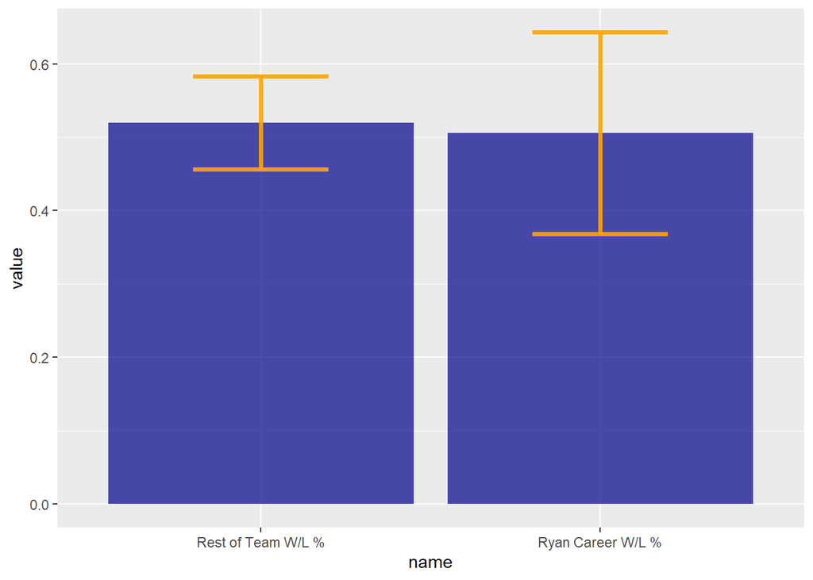

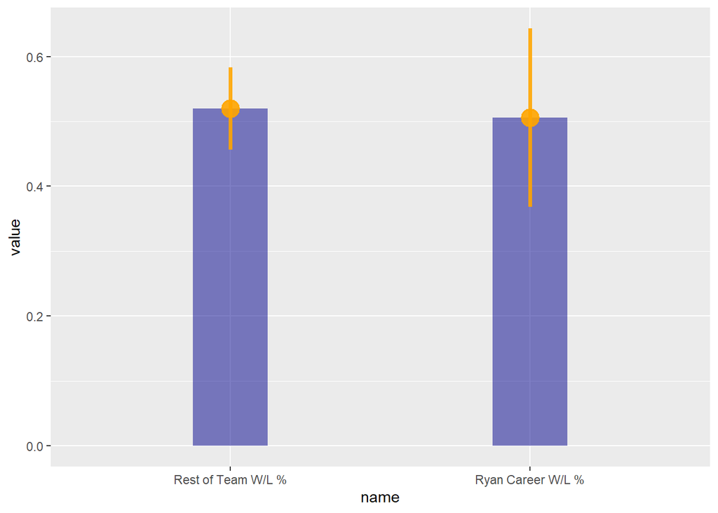

What we see is that Ryan had a slightly lower Win-Loss percentage than his teammates. On it’s own, that might be damning to him as a Hall of Famer. Thankfully, those other teammates included other great pitchers like Tom Seaver, Frank Tanana, Joe Niekro, Don Sutton, Mike Scott, Bob Knepper, and Kevin Brown.

As with his career when it came to Cy Young votes, Ryan was frequently the 2nd or 3rd best pitcher on his own team. He was a great pitcher, who’s longevity, power, and ability to adapt warrant him being in the Hall, but he is also an example of how his legacy sometimes gets us to forget some of the greats he played with.